# Honest causal forests

References: from Ian Lundberg, **Athey & Imbens (2016)**, Athey, Tibshirani, & Wager (2018), Wager & Athey (2018)

Causal forests are a way to use regression trees to estimate heterogenous treatment effects.

## Notation

**Potential Outcomes and counterfactual causality**

We are interested in the potential counterfactuals of treatments. Simply put, we want to know, for a given treatment of individual $i$, $W_{i} \left[0,1\right]$, what the treatment effect is.

- Statistics: Rubin, Holland, Rosenbaum
- Economics: Heckman, Manski: `Treatment effects'

**Goal**

- Precise definition of causal effects.
- Formal model of causality against which we can assess the adequacy of various estimators.
- Causal questions: `what if'- questions.
- Extend the logic of randomized experiments to observational data.

**Example**

What is the effect of attending college on wages?

**Treatment:** Binary treatment $W_i=\{0,1\}$

- $W_i$: Attend college $(=1)$ or not $=0$.
- Potential outcomes: $Y_{i}$, one for each value of the treatment.
- $Y_{i}(1):$ Potential outcome if attending college.
- $Y_{i}(0):$ Potential outcome if not attending college.

For each individual, can only observe one outcome.

- $Y_{i}=Y_{i1}$ if $W_i=1$.
- $Y_{i}=Y_{i0}$ if $W_i=0$.

The individual level causal effect is defined as $\beta_i=Y_{i1}-Y_{i0}$.

The individual level causal effect `what would happen if the individual received treatment rather than control'.

- $Y_{i0}=Y_{i1} \rightarrow \beta_i=0$ There is no effect of college on wages.
- $Y_{i0} < Y_{i1} \rightarrow \beta_i>0$ There is a positive effect of college on wages.
- $Y_{i0} > Y_{i1} \rightarrow \beta_i<0$ There is a negative effect of college on wages.

Define the average causal/ average treatment effect as $$ATE=\mathbb{E}[\beta]=\mathbb{E}[Y_1]-\mathbb{E}[Y_0] $$

The average treatment effect is a difference at a population level: wages in the population if all individuals had attended college minus wages if all individual had not attended college.

The problem: in order to calculate the ATE we would need **potential** outcomes, but we only have **observed** outcomes.

**Comparing Observed Outcomes** $$Y_i=Y_{0i}+(Y_{1i}-Y_{0i})W_i $$

\begin{eqnarray*} \underset{\mbox{ Observed Differences in Earnings}}{\mathbb{E}[Y_{i}|W=1]-\mathbb{E}[Y_i|W=0]}&=&\underset{\mbox{ Average treatment effect on the treated}}{\mathbb{E}[Y_{1i}-Y_{0i}|W=1]}\\ &+&\underset{\mbox{ Selection Bias}}{\mathbb{E}[Y_{0i}|W=1]-\mathbb{E}[Y_{0i}|W=0]}\end{eqnarray*}

A sufficient condition for a standard estimator comparing observed outcomes to consistently estimate the ATE is

$$\mathbb{E}[Y_1|W=1]=\mathbb{E}[Y_1|W=0]=\mathbb{E}[Y_1]$$

in words: the mean potential outcome under treatment for those in the treatment group equals the mean potential outcome under treatment for those in the control group.

$$\mathbb{E}[Y_0|W=1]=\mathbb{E}[Y_0|W=0]=\mathbb{E}[Y_0]$$

in words: the mean potential outcome under control for those in the treatment group equals the mean potential outcome under control for those in the control group, because then:

$$\mathbb{E}[Y_1|W=1]-\mathbb{E}[Y_0|W=0]=E[Y_1]-\mathbb{E}[Y_0]$$

This can be achieved by assigning people randomly into treatment and control groups.

The main assumption maintained here:

**Assumption 1 (Unconfoundedness)**

$$ \left[ W_{i} \perp\!\!\!\perp \left(Y_{i}(0), Y_{i}(1)\right) \mid X_{i} \right] $$

Causal inference: A missing data problem:

\begin{equation} \begin{aligned} \overline{\tau} &=\overline{Y}_{i : W_{i}=1}(1)-\overline{Y}_{i : W_{i}=0}(0) \\ &=1-0.5 \\ &=0.5 \end{aligned} \end{equation}

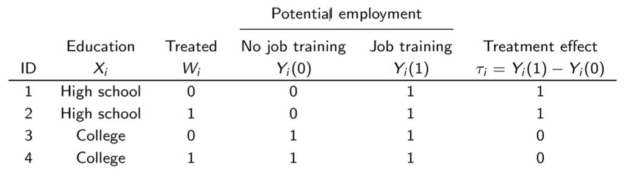

But: we have a missing data problem:

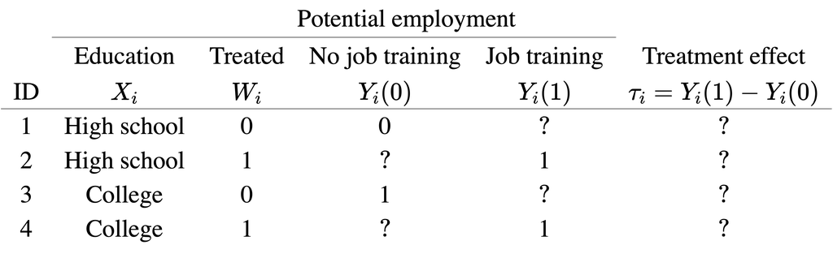

What if we want to study $\tau(x) \equiv \mathbb{E}\left[Y_{i}(1)-Y_{i}(0) \mid X_{i}=x\right]$, the conditional average treatment effect?

Standard regression:

\begin{equation} Y=\beta_0+\beta_1 X+\beta_2 W +{\beta_3} X \times W+\varepsilon\end{equation}

What if there are dozens of $X$ variables?

What if $X$ is continuous?

It's hard to know which subgroups of $X$ might show interesting effect heterogeneity

So: start with a simpler prediction problem: which subgroups of $X$ have very different **average** outcomes?

The basic idea: Compare the outcomes of people with similar covariate profiles in different conditions and use these differences as estimates of a treatment effect.

Then: assign that treatment effect to everyone in that specific subgroup, and any future people we are trying to target are assigned that same treatment effect. We can use these predicted treatment effects to inform targeting.

**Prediction: one tree**

Calculate

- $ \mathrm{MSE}_{0}=\frac{1}{n} \sum\left(Y_{i}-\overline{Y}\right)^{2} $.
  - $\mathrm{MSE}_{1}=\frac{1}{n} \sum\left(Y_{i}-\hat{Y}_{j : x_{j} \in R_{k}(j, s)}\right)^{2}$
  - $\begin{array}{c}{\text { All observations }} \\ {\swarrow} \searrow \\ {X_{i}<k} \, \,\, {X_{i} \geq k}\end{array}$
  - Choose $k$ to minimize $\mathrm{MSE}_{1}$.
  - Continue with further splits until we reach min. number of observations in each leaf.

Could we use this method to find causal treatment effects $\hat{\tau}(x)$ that are heterogenous between leaves?

**What is the problem with previous tree algorithms**? The objective function. We are interested in choosing those partitions of the controls that maximize the heterogeneity of the sample.

The setup:

We define a partition of the feature space $\mathbb{X}$, $\Pi=\left\{\ell_{1}, \ldots, \ell_{\#(\Pi)}\right\},$ with $\quad \cup_{j=1}^{\#(\Pi)} \ell_{j}=\mathbb{X}$.

where

- $\#(\Pi)$ is the number of elements in a partition
- $\mathbb{P}$ denote the space of partitions
- $\ell(x ; \Pi)$ denote the leaf $\ell \in \Pi$ such that $x \in \ell .$
- $\mathbb{S}$ be the space of data samples from a population
- $\pi: \mathbb{S} \mapsto \mathbb{P}$ be an algorithm that on the basis of a sample $\mathcal{S} \in \mathbb{S}$ constructs a partition.

**Example**

Suppose the feature space is $\mathbb{X}=\{L, R\} .$

Two possible partitions: $\Pi_{N}=\{L, R\}$ (no split) or $\Pi_{S}=\{\{L\},\{R\}\}$ (full split)

This implies that $\mathbb{P}=\left\{\Pi_{N}, \Pi_{S}\right\}=\{\{L, R\},\{\{L\},\{R\}\}\}$.

Given $\mathcal{S},$ the average outcomes in the two subsamples are $\bar{Y}_{L}$ and $\bar{Y}_{R} .$ A simple example of an algorithm is one that splits if the difference in average outcomes exceeds a threshold $c:$ $ \pi(\mathcal{S})=\left\{\begin{array}{cl} \{\{L, R\}\} & \text { if } \bar{Y}_{L}-\bar{Y}_{R} \leq c \\ \{\{L\},\{R\}\} & \text { if } \bar{Y}_{L}-\bar{Y}_{R}>c \end{array}\right. $

Given a partition $\Pi,$ define the conditional mean function $\mu(x ; \Pi)$ as $$ \mu(x ; \Pi) \equiv \mathbb{E}\left[Y_{i} \mid X_{i} \in \ell(x ; \Pi)\right]=\mathbb{E}\left[\mu\left(X_{i}\right) \mid X_{i} \in \ell(x ; \Pi)\right] $$

which can be viewed as a step-function approximation to $\mu(x)$ Given a sample $\mathcal{S}$ the estimated counterpart is $$ \hat{\mu}(x ; \mathcal{S}, \Pi) \equiv \frac{1}{\#\left(i \in \mathcal{S}: X_{i} \in \ell(x ; \Pi)\right)} \sum_{i \in \mathcal{S}: X_{i} \in \ell(x, \Pi)} Y_{i} $$

which is unbiased for $\mu(x ; \Pi)$

## Honest causal tree: what's different?

What makes it honest?

**Honest estimation:**

- One sample to choose partition/splitting
- One sample to estimate leaf effects/make predictions

**Why is the split critical?**

Fitting both on the training sample risks overfitting: Estimating many heterogeneous effects that are really just noise idiosyncratic to the sample.

We want to search for true heterogeneity, not noise.

Recall the example from above:

$\bar{Y}_{L}-\bar{Y}_{R}$ is in general an unbiased estimator for the difference in the population conditional means $\mu(L)-\mu(R),$

However: if we condition on finding that $\bar{Y}_{L}-$ $\bar{Y}_{R} \geq c$ in a particular sample, we expect that $\bar{Y}_{L}-Y_{R}$ is larger than the population analog.

In a normal tree: we make splits based on minimizing the MSE in a test set. Here: we do not know the "true" treatment effect(s).

The splitting subsample is used to perform the splits and thus grow the tree. The estimating subsample is then used to make the predictions. That is, all observations in the estimating subsample are dropped down the previously-grown tree until it falls into a terminal node. The prediction of the treatment effects is then given by the difference in the average outcomes between the treated and the untreated observations of the estimating subsample in the terminal nodes.

Formally: Given a partition $\Pi$ define the MSE, average over a test sample $\mathcal{S}^{\text {te }}$ and the conditional mean is estimated on an estimation sample $\mathcal{S}^{\text {est }},$ as \begin{equation} \operatorname{MSE}_{\mu}\left(\mathcal{S}^{\mathrm{te}}, \mathcal{S}^{\mathrm{est}}, \Pi\right) \equiv \frac{1}{\#\left(\mathcal{S}^{\mathrm{te}}\right)} \sum_{i \in \mathcal{S}^{\mathrm{ie}}}\left\{\left(Y_{i}-\hat{\mu}\left(X_{i} ; \mathcal{S}^{\mathrm{est}}, \Pi\right)\right)^{2}-Y_{i}^{2}\right\} \end{equation}

Therefore: the honest criterion

$$Q^{H}(\pi) \equiv-\mathbb{E}_{\mathcal{S}^{\text {est }}, \mathcal{S}^{\text {est }}, \mathcal{S}^{\text {tr }}}\left[\operatorname{MSE}_{\mu}\left(\mathcal{S}^{\text {te }}, \mathcal{S}^{\text {est }}, \pi\left(\mathcal{S}^{\text {tr }}\right)\right)\right]$$

as opposed to the traditional CART criterion function

$$Q^{C}(\pi) \equiv-\mathbb{E}_{\mathcal{S}^{\mathrm{te}}, \mathcal{S}^{\mathrm{tr}}}\left[\operatorname{MSE}_{\mu}\left(\mathcal{S}^{\mathrm{te}}, \mathcal{S}^{\mathrm{tr}}, \pi\left(\mathcal{S}^{\mathrm{tr}}\right)\right)\right]$$

where the same training sample is used to construct and estimate the tree.

## Causal tree

Explicitly searches for the subgroups where the treatment effects differ most.

A typical regression tree might split the data by asking, “What variable and value would reduce the mean squared error the most if we made a split at that value of that variable?” In doing so, the typical tree predicts Y

The causal tree uses splitting criteria that explicitly balances the two things they are trying to do: first, finding where treatment effects most differ, and second, estimating the treatment effects accurately. Thus, the tree is “causal” because it is fit by asking the data, ''Where can we make a split that will produce the biggest difference in treatment effects across leaves, but still give us an accurate estimate of the treatment effect?"

Formally: For each sample observe the triple $\left(Y_{i}^{\mathrm{obs}}, X_{i}, W_{i}\right) .$ For a sample $\mathcal{S}$ let $\mathcal{S}_{\text {treat }}$ and $\mathcal{S}_{\text {control }}$ denote the subsamples of treated and control units, respectively, with cardinality $N_{\text {treat }}$ and $N_{\text {control }}$ respectively, and let $p=N_{\text {treat }} / N$ be the share of treated units. The concept of a tree remains the same as in the previous section. Given a tree $\Pi$, define for all $x$ and both treatment levels $w$ the population average outcome $$ \mu(w, x ; \Pi) \equiv \mathbb{E}\left[Y_{i}(w) \mid X_{i} \in \ell(x ; \Pi)\right] $$ and the average causal effect $$ \tau(x ; \Pi) \equiv \mathbb{E}\left[Y_{i}(1)-Y_{i}(0) \mid X_{i} \in \ell(x ; \Pi)\right]=\mu(1, x ; \Pi)-\mu(0, x ; \Pi) $$ The estimated counterparts are $$ \begin{aligned} \hat{\mu}(w, x ; \mathcal{S}, \Pi) & \equiv \frac{1}{\#\left(\left\{i \in \mathcal{S}_{w}: X_{i} \in \ell(x ; \Pi)\right\}\right)} \sum_{i \in S_{w}: X_{i} \in \ell(x ; \Pi)} Y_{i}^{\mathrm{obs}} \\ \hat{\tau}(x ; \mathcal{S}, \Pi) & \equiv \hat{\mu}(1, x ; \mathcal{S}, \Pi)-\hat{\mu}(0, x ; \mathcal{S}, \Pi) \end{aligned} $$ Define the MSE for treatment effects as $$ \operatorname{MSE}_{\tau}\left(\mathcal{S}^{\mathrm{te}}, \mathcal{S}^{\mathrm{est}}, \Pi\right) \equiv \frac{1}{\#\left(\mathcal{S}^{\mathrm{te}}\right)} \sum_{i \in \mathcal{S}^{\mathrm{te}}}\left\{\left(\tau_{i}-\hat{\tau}\left(X_{i} ; \mathcal{S}^{\mathrm{est}}, \Pi\right)\right)^{2}-\tau_{i}^{2}\right\} $$

The problem: In contrast to $\operatorname{MSE}_{\mu}\left(\mathcal{S}^{\text {te }}, \mathcal{S}^{\text {est }}, \Pi\right),$ the workhorse MSE function MSE $_{\tau}\left(\mathcal{S}^{\text {te }}, \mathcal{S}^{\text {est }}, \Pi\right)$ is infeasible, because we do not observe $\tau_{i} .$ However,it can be estimated.

Honest causal trees have two advantages:

1. We can model high-level interactions between covariates and the treatment effect ("moderators")
2. Through the honesty: We can show that the treatment effect estimate is **asymptotically normal**, i.e. the estimator is asymptotically unbiased **and** we can calcluate confidence intervals.

Extensions to causal forests:

- Causal random forests
- Inference for causal forests and causal random forests
- local linear random forests -...